# Invisible Ledger empirical backend audit

This notebook is a reproducible inspection layer for the 9 September 2026 backend. It deliberately keeps country reconstructions, issuer/segment records, quarterly accounting observations, market data, and BPS statistics in separate empirical modules. Counts across these layers are **not additive**.

```python
from pathlib import Path
import json
import pandas as pd
from IPython.display import display, Image, Markdown
ROOT = Path.cwd().resolve()
if ROOT.name == 'notebooks': ROOT = ROOT.parent
OUT = ROOT / 'outputs' / 'empirical_backend_2026-09-09'
assert OUT.exists(), OUT
summary = json.loads((OUT / 'findings_summary.json').read_text())
summary
```

```
{'generated_on': '2026-09-09',
 'source_files_profiled': 78,
 'csv_files_profiled': 66,
 'source_layer_csv_rows': 35972,
 'census_source_records': 195,
 'census_canonical_records': 169,
 'census_ratio_eligible_records': 165,
 'indonesia_extension_records': 9,
 'quarterly_accounting_records': 47,
 'strict_explicit_country_direct_pairs': 0,
 'candidate_indonesia_aligned_direct_annual_pairs': 14,
 'bps_provinces_with_complete_pair': 36,
 'bps_complete_province_years_2023_2024': 74,
 'interpretation': 'Counts belong to different, overlapping evidence families and must not be summed into one sample N.'}
```

## Observation census and admissible research designs

```python
families = pd.read_csv(OUT / 'sample_definition_summary.csv')
designs = pd.read_csv(OUT / 'candidate_research_designs.csv')
display(families[['sample_family','source_records_all_vintages','canonical_records','ratio_eligible_pairs','unique_platforms','min_year','max_year']])
display(designs)
```

|  | sample_family | source_records_all_vintages | canonical_records | ratio_eligible_pairs | unique_platforms | min_year | max_year |
| --- | --- | --- | --- | --- | --- | --- | --- |
| 0 | blibli_prospectus_candidates | 8 | 8 | 7 | 1 | 2019.0 | 2020.0 |
| 1 | blibli_q1_verified_replacement | 15 | 10 | 10 | 1 | 2022.0 | 2023.0 |
| 2 | blibli_reported_source_universe | 90 | 70 | 69 | 1 | 2021.0 | 2025.0 |
| 3 | bukalapak_annual_candidates | 5 | 5 | 4 | 1 | 2020.0 | 2024.0 |
| 4 | conditional_indonesia_country_reconstruction | 6 | 6 | 6 | 2 | 2021.0 | 2024.0 |
| 5 | historical_company_segment | 8 | 8 | 7 | 2 | 2017.0 | 2021.0 |
| 6 | indonesia_aligned_direct_segment | 3 | 3 | 3 | 1 | 2021.0 | 2023.0 |
| 7 | quarterly_company_accounting | 47 | 47 | 47 | 3 | 2022.0 | 2026.0 |
| 8 | recent_company_annual | 13 | 12 | 12 | 3 | 2022.0 | 2025.0 |

|  | design_id | design | geography | frequency | eligible_pairs_now | platforms_now | period_window | strength | binding_problem | advisor_decision_needed |
| --- | --- | --- | --- | --- | --- | --- | --- | --- | --- | --- |
| 0 | A | strict explicit-country direct annual pairs | Indonesia explicitly labelled by issuer | annual | 0 | 0 | none established | highest directness | No platform currently provides a direct Indone... | Whether this strict rule is required. |
| 1 | B | Indonesia-aligned direct issuer/segment annual... | Indonesia-aligned operations; not always expli... | annual | 14 | 3 | 2019-2025 unbalanced | direct reported transaction/revenue pairs | Blibli 3P includes online travel; Bukalapak Gr... | Whether Indonesia-aligned business scope is ac... |
| 2 | C | conditional Indonesia country reconstruction | Indonesia anchors plus allocation assumptions | annual | 9 | 3 | 2021-2024 unbalanced | preserves original Grab/Tokopedia/Shopee compa... | Grab and Shopee country pairs are model-depend... | Whether conditional cases belong in the core o... |
| 3 | D | company/segment quarterly accounting panel | listed platforms serving Indonesia; company/se... | quarterly | 47 | 3 | 2022Q1-2026Q1, platform-specific | source-reconciled repeated accounting observat... | Not Indonesia-only; business-model and deconso... | Whether it is supporting longitudinal evidence... |
| 4 | E | official BPS Indonesia business/statistical ev... | Indonesia and provinces | annual/cross-sectional | 74 | 0 | national indicators 2020-2024; province repeat... | official survey evidence on transactions, sale... | Different unit of analysis and definitions; pr... | Whether this becomes an independent validation... |

The strict direct-country annual design currently has no complete issuer-disclosed Indonesia pair. The expansion therefore offers alternatives rather than one automatically approved sample: 14 Indonesia-aligned direct annual platform/segment periods, 9 conditional Indonesia platform-years, 47 company/segment quarters, and official BPS business evidence.

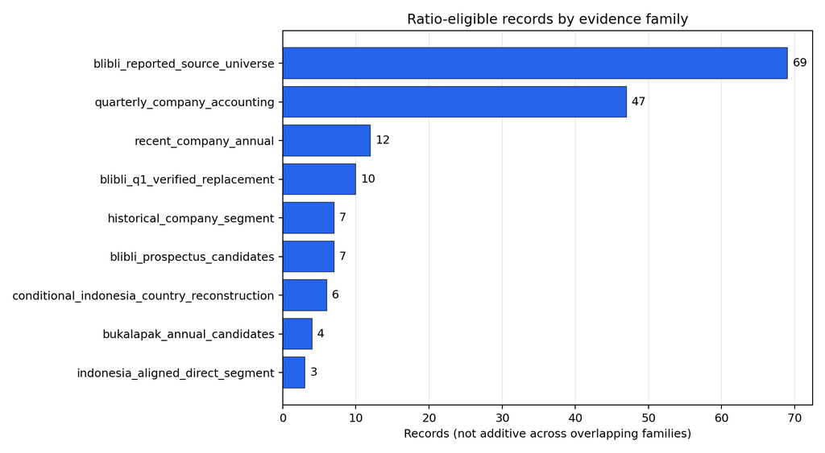

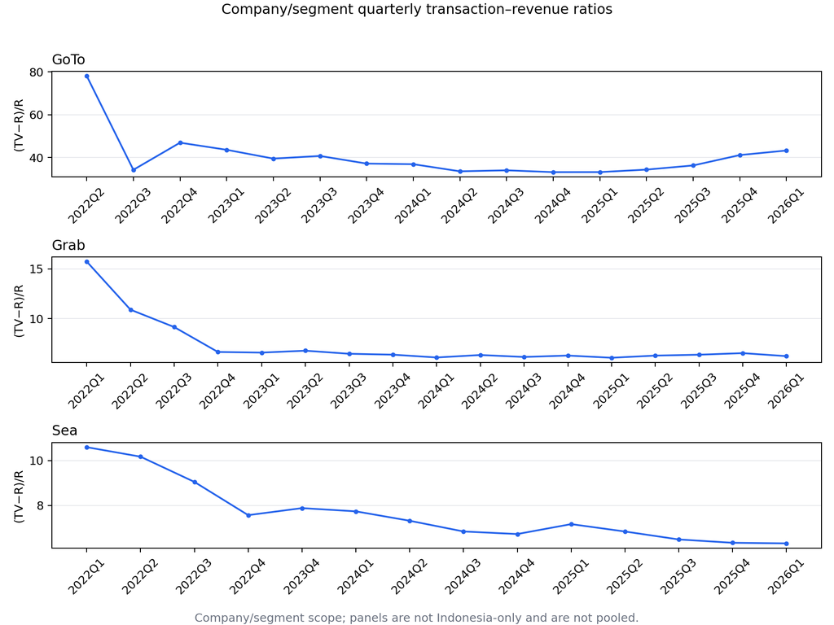

```python
display(Image(filename=str(OUT / 'charts' / 'sample_family_eligible_counts.png')))
display(Image(filename=str(OUT / 'charts' / 'quarterly_ratio_small_multiples.png')))
```

## Official Indonesia business evidence

|  | year | province_N | pearson_r | pearson_p | spearman_rho | spearman_p | business_count_weighted_r | interpretation |
| --- | --- | --- | --- | --- | --- | --- | --- | --- |
| 0 | 2023 | 36 | 0.263448 | 0.120550 | 0.342600 | 0.040814 | 0.490437 | Province-level descriptive association; not ca... |
| 1 | 2024 | 38 | 0.021777 | 0.896744 | 0.113032 | 0.499250 | 0.314271 | Province-level descriptive association; not ca... |

|  | overall_change_pearson_r | overall_change_pearson_p | overall_change_spearman_rho | overall_change_spearman_p | overall_change_weighted_r |
| --- | --- | --- | --- | --- | --- |
| 0 | 0.309453 | 0.066274 | 0.150975 | 0.379437 | 0.098798 |

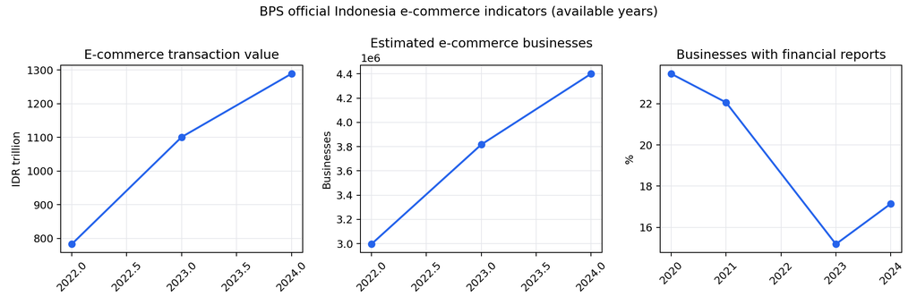

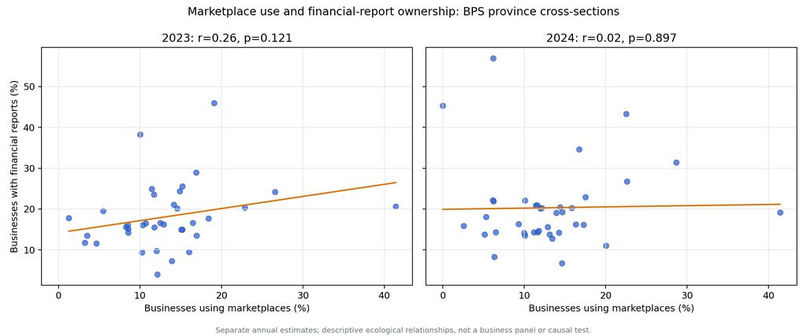

```python
annual_assoc = pd.read_csv(OUT / 'bps_province_associations_by_year.csv')
changes = pd.read_csv(OUT / 'bps_within_province_changes_2023_2024.csv')
display(annual_assoc)
display(changes[['overall_change_pearson_r','overall_change_pearson_p','overall_change_spearman_rho','overall_change_spearman_p','overall_change_weighted_r']].iloc[[0]])
display(Image(filename=str(OUT / 'charts' / 'bps_national_indicator_trends.png')))
display(Image(filename=str(OUT / 'charts' / 'bps_province_association_by_year.png')))
```

The province-level marketplace/financial-report association is not stable across 2023 and 2024. The repeated cross-sections therefore support descriptive measurement and channel-composition analysis, not a causal formalization claim. The national series shows rising transaction value and business counts alongside persistently limited financial-report ownership.

## Data-quality findings and excluded false expansions

```python
issues = pd.read_csv(OUT / 'data_quality_issues.csv')
yzuc = pd.read_csv(OUT / 'yzuc_refinitiv_panel_assessment.csv')
display(issues)
display(yzuc)
```

|  | severity | area | finding | required_treatment |
| --- | --- | --- | --- | --- |
| 0 | critical | main-sample definition | No expanded longitudinal sample is advisor-app... | Treat sample families as alternatives; do not ... |
| 1 | critical | geography | No verified strict direct country-level transa... | Separate explicit-country anchors, Indonesia-a... |
| 2 | high | Grab country construction | Country transaction value is inferred with a G... | Keep conditional; show rate sensitivity and av... |
| 3 | high | Shopee country construction | Country GMV is external and country revenue is... | Keep conditional; test market-size/share/rate ... |
| 4 | high | Blibli scope | 3P includes online travel and Group geography ... | Resolve segment and geographic eligibility bef... |
| 5 | high | Bukalapak geography | Group disclosures include overseas activity. | Use only with explicit issuer-scope framing or... |
| 6 | high | Bukalapak FY2024 | TPV covers 9 months while revenue covers 12 mo... | Exclude until a matched 9M revenue denominator... |
| 7 | high | event study | Contamination classifications remain unresolve... | Keep results exploratory until classifications... |
| 8 | medium | reporting vintages | Blibli observations repeat across releases and... | Preserve all vintages; designate one canonical... |
| 9 | high | Blibli Q1 extraction | Rows labelled 2023Q1 reproduce FY2022 values i... | Exclude the affected Q1 extraction until the i... |
| 10 | resolved | Blibli Q1 extraction | The official 1Q23 issuer PDF was recovered and... | Use blibli_q1_2023_corrected_extract.csv; reta... |
| 11 | medium | revenue definitions | Gross, net, service, and total revenue are not... | Use a consistent denominator within each compa... |
| 12 | medium | structural breaks | Grab business-model changes and Tokopedia deco... | Flag or segment time series around breaks; use... |
| 13 | medium | row-count interpretation | Source rows, inputs, scenarios, annual totals,... | Report N separately by observation grain and u... |

|  | dataset_id | registered_rows | registered_columns | claimed_grain | actual_nonmissing_fiscal_years | actual_unique_rics | actual_relevant_rics | assessment | admission_decision | reason |
| --- | --- | --- | --- | --- | --- | --- | --- | --- | --- | --- |
| 0 | refinitiv_fundamental_annual_panel | 227 | 8 | instrument_fiscal_year | 0 | 227 | GOTO.JK | The registered parquet is an FY0 cross-section... | exclude_from_longitudinal_expansion | It cannot supply a historical panel or add val... |

The Refinitiv registry entry labelled as an annual panel is an FY0 snapshot with all fiscal years missing, so its 227 rows are excluded from longitudinal sample counts. A legacy Blibli 1Q23 extraction shifted FY22/1Q23/1Q22 columns; the issuer PDF has been recovered and a corrected extract is stored separately while the old rows remain excluded lineage.

## Reproduction conclusion

The backend now supports a much richer measurement study than the original three-row workbook, but it does not create one giant homogeneous sample. The defensible architecture is modular: Indonesia-focused multi-year issuer/segment evidence, conditional country reconstructions, source-reconciled quarterly accounting records, official BPS business statistics, and an exploratory market layer. Advisor approval is still required for the main-sample boundary.